# Rotations & Translations Lin Alg

### **NOTES ON STATISTICS, PROBABILITY and MATHEMATICS**

### Plotting in the Complex Plane:

The code in R can be found [here](https://github.com/RInterested/PLOTS/blob/master/EULER'S%20EQUATION).

The $x$ coordinate is the real part, and the $y$ coordinate, the imaginary part.

Translation can be achieved by adding a complex number to every point. Scaling is done by multiplying by a scalar.

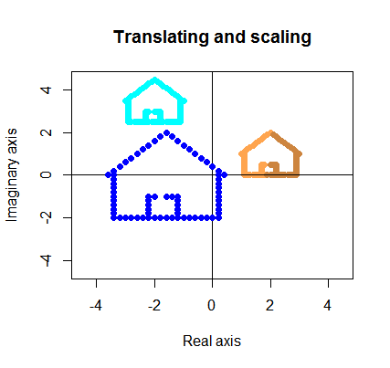

Horizontal and vertical flips require separating the real from the imaginary components before multplying either the real part by $-1$ to achieve a horizontal flip; or the imaginary part by $-1$ for a vertical flip:

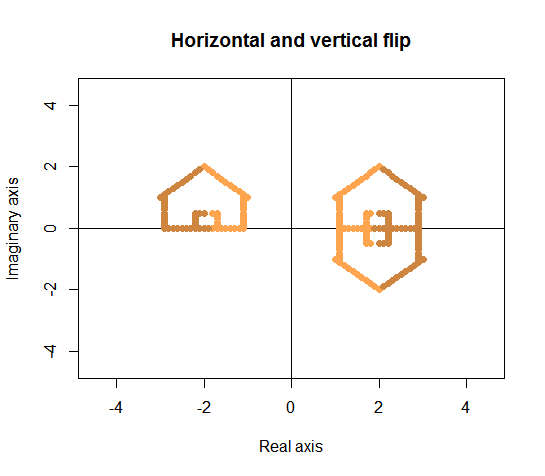

Inverting is accomplished simply multiplying by the scalar $-1$, and the way to picture it is by realizding that the $-1$ changes the the sign of the real and imaginary components.

To rotate $90$ degrees we multiply by $i$:

$i \times (x + y*i) = -y +x*i.$

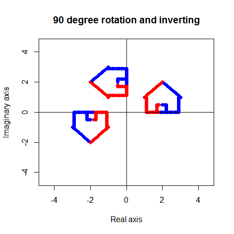

Rotating by another angle requires some background:

*Argument of a complex angle*: angle between the vectorial representation of the complex number and $1 + 0i.$ This correponds to the angle, measured in radians, between the x axis and the arrow representing the complex number.

Euler’s formula codes every point in the unit circle as:

$\Large e^{\theta\,i}$ with $\large \theta$ being the argument.

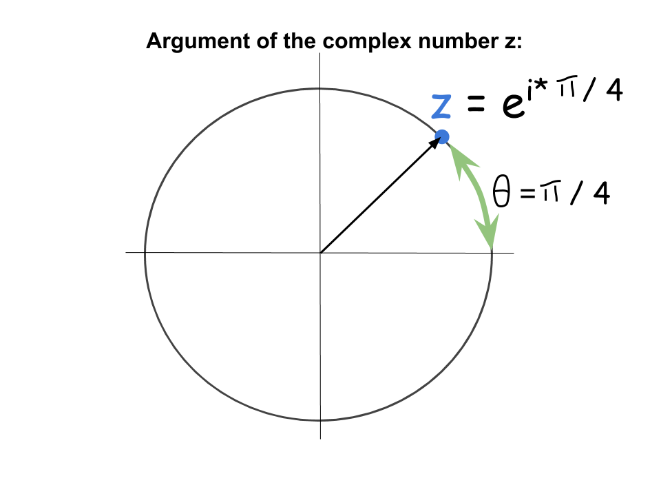

The trick is to divide the circle $2\,\pi$ into an arbritary number of equally spaced points, for instance, $200$: $2\,\pi/200$. In this way, every point can be rotated a given amount of these divisions of the circle (e.g. $n$) as follows ([Euler’s formula](https://en.wikipedia.org/wiki/Euler%27s_formula)):

$\Huge e^{\,\huge i\times\,n \,\times \frac{2\pi}{200}}= \Large \cos(n \,\times \frac{2\pi}{200}) + i\,\sin(n \,\times \frac{2\pi}{200}).$

The code in R is:

```
exp(#_of_"slices" * 1i * (2*pi / total_number_slices)) * complex_#s
```

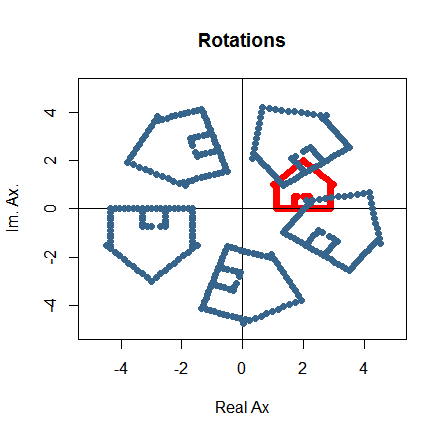

[Home Page](http://rinterested.github.io/statistics/index.html)

**NOTE: These are tentative notes on different topics for personal use - expect mistakes and misunderstandings.**